# ds202_lab3_team

HanSun, XinyiZhu

2020/2/19

```r
dat <- readxl::read_xls('GSS.xls')
names(dat) <- c('year','id','marital','sex','party','happiness','ballot')
dat <- dat %>% drop_na()
str(dat)
```

```
## Classes 'tbl_df', 'tbl' and 'data.frame':    64814 obs. of  7 variables:
##  $ year     : num  1972 1972 1972 1972 1972 ...
##  $ id       : num  1 2 3 4 5 6 7 8 9 10 ...
##  $ marital  : chr  "Never married" "Married" "Married" "Married" ...
##  $ sex      : chr  "Female" "Male" "Female" "Female" ...
##  $ party    : chr  "Ind,near dem" "Not str democrat" "Independent" "Not str democrat" ...
##  $ happiness: chr  "Not too happy" "Not too happy" "Pretty happy" "Not too happy" ...
##  $ ballot   : chr  "Not applicable" "Not applicable" "Not applicable" "Not applicable" ...
```

1. How does the happiness of a respondent relate to the marriage status?

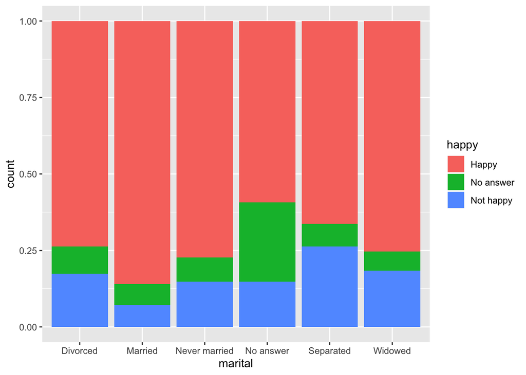

```r
dat <- dat %>% mutate(happy = case_when(
  happiness == "Not too happy" ~ "Not happy",
  happiness == "Pretty happy"  ~ "Happy",
  happiness == "Very happy"  ~ "Happy",
  happiness == "Don't know" ~ "No answer",
  happiness == "No answer" ~ "No answer",
  happiness == "Not applicable" ~ "No answer"))
dat %>%
  filter(!is.na(marital)) %>%
  ggplot(aes(x= marital, fill = happy)) + geom_bar(position = 'fill')
```

For married people, about 80% said they were happy. About 70% of the separated people said they were happy. It is, therefore, easier for married people to be happy. About 25% of the separated people said they were not happy. And less than 10% of married people say they are not happy.

2. Does the sex of the respondent affect the relationship you found in Q1?

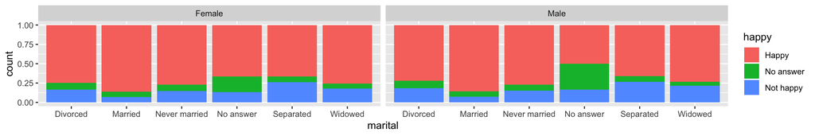

```r
dat %>%
  filter(!is.na(sex)) %>%
  ggplot(aes(x= marital, fill = happy)) + geom_bar(position = 'fill')+facet_grid(~sex)
```

In fact, the gender of the respondents did not affect the findings in Q1.

3. How does the happniess of a respondent relate to the political party affiliation?

```r
dat[is.na(dat$`party`), ]
```

```
## # A tibble: 0 x 8
## # … with 8 variables: year <dbl>, id <dbl>, marital <chr>, sex <chr>,
## #   party <chr>, happiness <chr>, ballot <chr>, happy <chr>
```

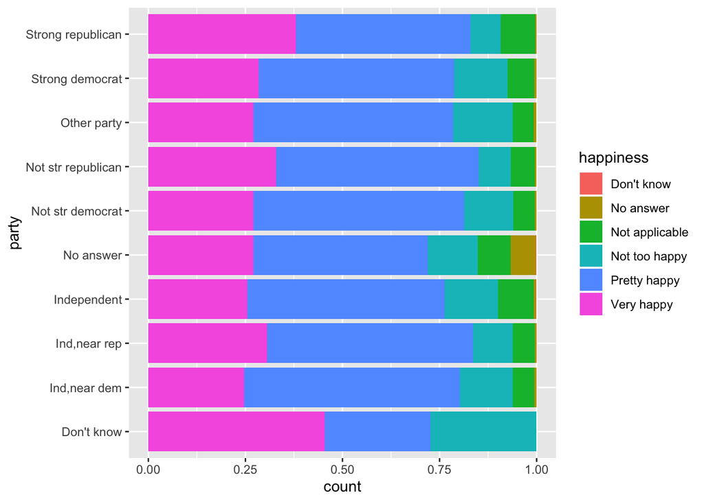

```r
dat1 <- dat[!is.na(dat$'party'), ]

ggplot(dat1, aes(x=party, fill=happiness)) + geom_bar(position='fill') + coord_flip()
```